# Студент

Скрипин Антон ФТ-360008

# Лабораторная - Изучение свойств объектов - изображений Python

### Цели

**Часть 1. Ввод изображения**

**Часть 2: Измерение и изменение характеристик изображения**

### История/Cценарий

В этой лабораторной работе вы будете исследовать характеристики объектов-изображенй Python

### Необходимые ресурсы

- 1 ПК с доступом в Интернет
- Библиотеки Python: numpy, matplotlib, scimage
- Файл данных: canvas.png

#### Шаг 1. Импорт необходимых библиотек Python.

На этом этапе вы импортируете библиотеки Python, которые потребуются для выполнения практического задания.

```python
#Ячейка №1
import skimage
import os
import matplotlib.pyplot as plt
from skimage import io
from skimage import data
from skimage.viewer import ImageViewer
```

#### Шаг 2. Создание объекта-изображения из файла .png

Используя функцию imread() библиотеки io сформируйте объект-изображение canvas

```python
#Ячейка №2
filename = 'canvas.png'
canvas = io.imread(filename)
```

#### Шаг 3. Отображение типа объекта-изображения

Используя функцию type() отобразите тип объекта-изображения canvas

```python
#Ячейка №3
type(canvas)
```

```
numpy.ndarray
```

#### Шаг 4. Отображение структуры объекта-изображения

Используя метод shape отобразите структуру объекта-изображения canvas

```python
#Ячейка №4
canvas.shape
```

```
(490, 680, 4)
```

#### Шаг 5. Отображение содержания объекта-изображения

Используя метод view отобразите состав объекта-изображения canvas

```python
#Ячейка №5
canvas.view()
```

```
array([[[ 83,  81,  82, 255],
        [ 83,  81,  82, 255],
        [ 83,  81,  82, 255],
        ...,
        [129, 127, 128, 255],
        [129, 127, 128, 255],
        [129, 127, 128, 255]],

       [[ 83,  81,  82, 255],
        [ 83,  81,  82, 255],
        [ 83,  81,  82, 255],
        ...,
        [129, 127, 128, 255],
        [129, 127, 128, 255],
        [129, 127, 128, 255]],

       [[ 83,  81,  82, 255],
        [ 83,  81,  82, 255],
        [ 83,  81,  82, 255],
        ...,
        [129, 127, 128, 255],
        [129, 127, 128, 255],
        [129, 127, 128, 255]],

       ...,

       [[ 83,  81,  82, 255],
        [ 83,  81,  82, 255],
        [ 83,  81,  82, 255],
        ...,
        [126, 124, 125, 255],
        [126, 124, 125, 255],
        [126, 124, 125, 255]],

       [[ 83,  81,  82, 255],
        [ 83,  81,  82, 255],
        [ 83,  81,  82, 255],
        ...,
        [126, 124, 125, 255],
        [126, 124, 125, 255],
        [126, 124, 125, 255]],

       [[ 83,  81,  82, 255],
        [ 83,  81,  82, 255],
        [ 83,  81,  82, 255],
        ...,
        [126, 124, 125, 255],
        [126, 124, 125, 255],
        [126, 124, 125, 255]]], dtype=uint8)
```

#### Шаг 6. Отображение объекта-изображения в полноэкранном вьюере

Для отображение объекта-изображения в полноэкранном вьюере используйте объект viewer, а также функции ImageViewer и viewer.show()

```python
#Ячейка №6
viewer = ImageViewer(canvas)
viewer.show()
```

```
[]
```

Выходное изображение:

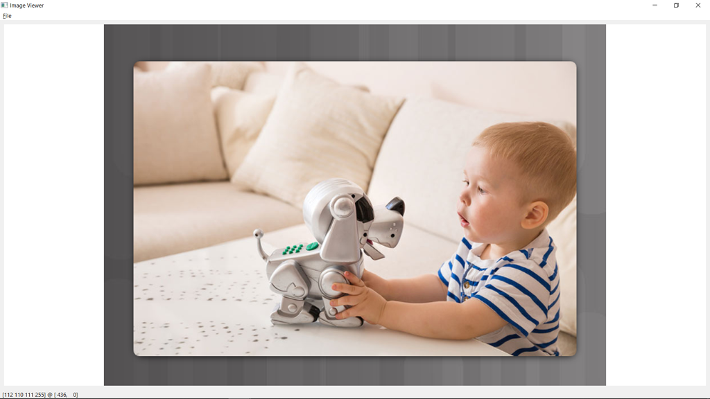

#### Шаг 7. Отображение объекта-изображения во вьюере ячейки

Для отображение объекта-изображения во вьюере ячейки используйте объект viewer, а также функции plt.imshow и plt.show()

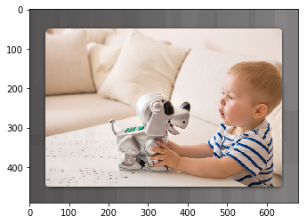

```python
#Ячейка №7
import matplotlib.pyplot as plt
plt.imshow(canvas)
plt.show()
```

#### Шаг 8. Пороговая нормализация объекта-изображения

С помощью функции copy() создайте объект canvas_mask и замените в нем начения выше 150 на 255 (белый). Отобразите нормализованный объект во вьюере ячейки.

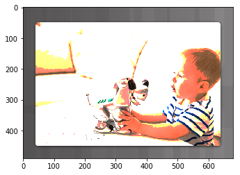

```python
#Ячейка №8
mask2 = canvas > 150 #применяем пороговую нормализацию объекта
canvas_mask = canvas.copy()
canvas_mask[mask2] = 255
plt.imshow(canvas_mask)
plt.show()
```

#### Шаг 9. Добавление шума к объекту-изображению

Используя приводимую ниже функцию Pepper (или любые другие средства) добавьте случайный шум к объекту-изображению Отобразите нормализованный объект во вьюере ячейки.

**Параметры функции pepper:**

```
image - объект
rate - частота шума
color - "цвет" шума
```

```python
def pepper (image,rate,color): #функция для добавления шума к изображению
    from random import uniform
    a,b,c=image.shape
    image_pep = image + 0
    for i in range(a):
        for j in range(b):
            if (uniform (0,1) > 1-rate) :
                image_pep[i][j] = [color,color,color,255]
    return (image_pep)
```

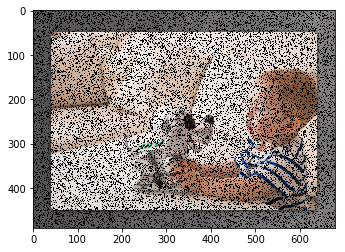

```python
#Ячейка №9
canvas_pep = pepper(canvas,0.25,0)
canvas_pep.view()
plt.imshow(canvas_pep)
plt.show() #на выходе получаем зашумленное изображение
```

#### Шаг 10. Устранение шума из объекта-изображения

Используя собственную функцию или известные вам стандартные средства Python устраните случайный шум из объекта-изображения. Отобразите нормализованный объект во вьюере ячейки.

```python
def unpepper (image,rate,color): #функция для устранения шума из зашумленного объекта
    a,b,c=image.shape
    image_pep=image+0
    for i in range (a-1):
        for j in range (b-1):
            if image[i][j][0]==image[i][j][1]==image[i][j][2]==color:
                image_pep[i][j]=image[i+1][j]
    return (image_pep)
#########Возможно для последующих курсов было бы более понятно как выолнять последнее задание, если бы в 9 задание был бы
#приведен помимо кода готовой функции также плюсом код объяснения, или лучше было бы не давать полностью готовый код,
# а давать лишь шаблоны заготовки с подробным объеснением, что делать дальше, а дальше реализация оставалась бы на стороне
# студента. На мой взгляд это бы улучшило бы восприятие материала (Лично мне подход в практике 4a2 понравился гораздо больше,
# т.к нет соблазна использовать готовый код, а искать решение и добывать информацию из документации python)
```

[figure not shown]

```python
canvas_pep = unpepper(canvas_pep,0.25,0) #на вход подается зашумленное изображение с показателем 0.25
canvas_pep.view()
plt.imshow(canvas_pep)
plt.show()
```

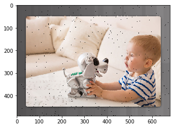

```python
canvas_pep = unpepper(canvas_pep,0.5,0) #на вход подается зашумленное изображение с показателем 0.5
canvas_pep.view()
plt.imshow(canvas_pep)
plt.show()
```

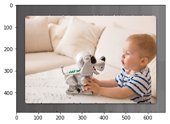

```python
canvas_pep = unpepper(canvas_pep,1,0) #на вход подается зашумленное изображение с показателем 1
canvas_pep.view()
plt.imshow(canvas_pep)
plt.show()
```